# Jurkat project - Enrichment

Juba

2026-01-08

In the first part of the analysis, we performed a `DE Analysis` to identify the **DEGs** between **Jurkat cells** (treated or not with H151). This was followed by a `PE Analysis`, focusing specifically on the enrichment of **downregulated genes**, which led to the identification of a set of **significantly enriched GO terms**.

In this second part of the project, we perform a detailed inspection of the enriched terms to better understand their biological relevance and relationships.

Importing the data

```r
goObject <- readRDS(paste0(out_obj, "goObj_downDegs.rds"))
goResults <- read_xlsx(paste0(out_obj, "goResults_downDegs.xlsx"))
deaResults <- read_xlsx(paste0(out_obj, "dea_results_filt.xlsx"))
```

Overview of the terms

```
## leukocyte activation                                                            : 54/993
## response to endoplasmic reticulum stress                                        : 21/277
## regulation of cell activation                                                   : 35/648
## cell-cell adhesion                                                              : 46/986
## multicellular organismal-level homeostasis                                      : 41/832
## lymphocyte activation                                                           : 40/824
## regulation of leukocyte activation                                              : 32/588
## integrated stress response signaling                                            : 8/48
## myeloid leukocyte activation                                                    : 18/247
## response to lipid                                                               : 42/946
## response to topologically incorrect protein                                     : 14/160
## response to unfolded protein                                                    : 13/143
## circulatory system process                                                      : 31/619
## T cell activation                                                               : 30/593
## endothelial cell migration                                                      : 19/287
## regulation of T cell mediated immunity                                          : 11/108
## cell-cell adhesion via plasma-membrane adhesion molecules                       : 18/280
## regulation of leukocyte differentiation                                         : 20/337
## positive regulation of response to external stimulus                            : 31/666
## toll-like receptor signaling pathway                                            : 9/82
## response to nutrient levels                                                     : 26/517
## negative regulation of immune system process                                    : 27/549
## homophilic cell adhesion via plasma membrane adhesion molecules                 : 13/168
## regulation of ferroptosis                                                       : 4/12
## endoplasmic reticulum unfolded protein response                                 : 9/85
## regulation of T cell mediated cytotoxicity                                      : 7/51
## leukocyte activation involved in inflammatory response                          : 7/52
## response to ketone                                                              : 15/224
## regulation of response to biotic stimulus                                       : 27/564
## regulation of heat generation                                                   : 4/13
## detection of molecule of bacterial origin                                       : 4/13
## ferroptosis                                                                     : 4/13
## leukocyte differentiation                                                       : 29/629
## inflammatory response                                                           : 38/924
## positive regulation of cytokine production                                      : 25/510
## macrophage activation                                                           : 10/112
## viral entry into host cell                                                      : 12/159
## cell junction organization                                                      : 35/839
## T cell mediated immunity                                                        : 11/138
## regulation of hemopoiesis                                                       : 22/433
```

[output cut: 46 more lines]

```
## cellular response to topologically incorrect protein                            : 9/114
## positive regulation of response to biotic stimulus                              : 20/416
## regulation of cell-cell adhesion                                                : 23/510
## IRE1-mediated unfolded protein response                                         : 4/21
## epithelial cell proliferation                                                   : 22/482
## response to hormone                                                             : 35/916
## natural killer cell mediated cytotoxicity directed against tumor cell target    : 3/10
## regulation of natural killer cell mediated immune response to tumor cell        : 3/10
## anterograde dendritic transport                                                 : 3/10
## regulation of T cell activation                                                 : 19/393
## vascular process in circulatory system                                          : 15/276
## regulation of translation in response to stress                                 : 4/22
## regulation of cardiac muscle cell differentiation                               : 4/22
## lymphocyte differentiation                                                      : 20/426
## regulation of adaptive immune response                                          : 13/221
```

# Terms inspections

## Semantic similarity analysis

https://yulab-smu.top/biomedical-knowledge-mining-book/01-semantic-similarity.html

Semantic similarity analysis aims to **quantify how close biological concepts are**, not based on gene overlap alone, but on their **meaning within an ontology**. In the context of Gene Ontology (GO), each term is part of a **structured graph (a Directed Acyclic Graph, DAG)** where nodes represent biological concepts and edges encode relationships such as *is_a* or *part_of*.  
Instead of treating enriched GO terms as independent entities, semantic similarity allows us to **compare terms by exploiting this structure**, capturing shared biological context even when the associated gene sets differ.

In practice, semantic similarity helps to **reduce redundancy** in enrichment results, **group related GO terms**, and highlight **functional modules** rather than long, partially overlapping lists of terms. This is particularly useful in Pathway Enrichment Analysis (PEA), where many significant terms may describe closely related biological processes at different levels of granularity.

Several semantic similarity measures exist, broadly divided into **information-content–based methods** (e.g. Resnik, Lin, Jiang–Conrath) and **graph-based methods**. In this work, we use the **Wang method**, a graph-based approach that evaluates similarity by considering the **shared ancestors of two GO terms** and their **positions within the GO DAG**. By weighting contributions from parent terms according to their distance and relationship type, the Wang method provides a **biologically intuitive measure of functional relatedness**, independent of external annotation frequencies.

Wang semantic similarity method

The Wang method defines the semantic similarity between two GO terms by explicitly leveraging the **structure of the GO Directed Acyclic Graph (DAG)**. Each GO term is assigned a **semantic value (SV)**, computed as the sum of contributions from all its ancestor terms in the DAG, where **closer ancestors contribute more strongly** than distant ones. These contributions are propagated through GO relationships using predefined edge weights, ensuring that the **topological context** of each term is preserved. The semantic similarity between two terms is then calculated as the **normalized overlap of their semantic values**, providing a graph-based, biologically intuitive measure of functional relatedness independent of gene annotation frequencies.

The Wang semantic similarity between two GO terms *A* and *B* is computed as:

$$S_A(t) =
\begin{cases}
1, & \text{if } t = A \\
\max\limits_{t' \in \text{children}(t)} \left( w_e \times
S_A(t') \right), & \text{if } t \neq A
\end{cases}$$

where $S_A(t)$ is the **semantic contribution (S-value)** of term $t$ to term $A$, and $w_e$ is the weight associated with the GO relationship between $t$ and its child $t'$.

The **semantic value** of term $A$ is then defined as:

$$SV(A) = \sum_{t \in T_A} S_A(t)$$

Finally, the Wang semantic similarity between terms $A$ and $B$ is given by:

$$\mathrm{sim}_{\text{Wang}}(A,B) =
\frac{\sum_{t \in T_A \cap T_B} \left( S_A(t) + S_B(t) \right)}
{SV(A) + SV(B)}$$

## Terms correlation

Now, let’s inspect the similarity between the terms using Wang semantic similarity. First let’s visualize the `similarity matrix`!

Similarity scores are between 0 and 1, the closer to 1 the more similar are the 2 terms

|  | GO:0045321 | GO:0034976 | GO:0050865 | GO:0098609 | GO:0048871 | GO:0046649 | GO:0002694 | GO:0140467 | GO:0002274 | GO:0033993 | GO:0035966 | GO:0006986 | GO:0003013 | GO:0042110 | GO:0043542 | GO:0002709 | GO:0098742 | GO:1902105 | GO:0032103 | GO:0002224 | GO:0031667 | GO:0002683 | GO:0007156 | GO:0110075 | GO:0030968 | GO:0001914 | GO:0002269 | GO:1901654 | GO:0002831 | … |
| --- | --- | --- | --- | --- | --- | --- | --- | --- | --- | --- | --- | --- | --- | --- | --- | --- | --- | --- | --- | --- | --- | --- | --- | --- | --- | --- | --- | --- | --- | --- |
| GO:0045321 | 1 | 0.224 | 0.432 | 0.283 | 0.138 | 0.852 | 0.607 | 0.224 | 0.852 | 0.119 | 0.117 | 0.105 | 0.141 | 0.748 | 0.156 | 0.128 | 0.241 | 0.189 | 0.094 | 0.191 | 0.119 | 0.305 | 0.212 | 0.168 | 0.136 | 0.159 | 0.674 | 0.107 | 0.112 | … |
| GO:0034976 | 0.224 | 1 | 0.185 | 0.214 | 0.1 | 0.182 | 0.131 | 0.723 | 0.182 | 0.183 | 0.356 | 0.298 | 0.095 | 0.153 | 0.104 | 0.074 | 0.173 | 0.083 | 0.156 | 0.307 | 0.183 | 0.091 | 0.146 | 0.117 | 0.501 | 0.101 | 0.307 | 0.165 | 0.185 | … |
| GO:0050865 | 0.432 | 0.185 | 1 | 0.235 | 0.195 | 0.365 | 0.715 | 0.185 | 0.365 | 0.085 | 0.088 | 0.076 | 0.104 | 0.317 | 0.127 | 0.129 | 0.197 | 0.278 | 0.22 | 0.418 | 0.085 | 0.294 | 0.171 | 0.394 | 0.304 | 0.237 | 0.294 | 0.077 | 0.289 | … |
| GO:0098609 | 0.283 | 0.214 | 0.235 | 1 | 0.123 | 0.238 | 0.167 | 0.214 | 0.238 | 0.101 | 0.102 | 0.088 | 0.123 | 0.206 | 0.144 | 0.041 | 0.837 | 0.106 | 0.081 | 0.181 | 0.101 | 0.112 | 0.726 | 0.157 | 0.128 | 0.09 | 0.186 | 0.09 | 0.097 | … |
| GO:0048871 | 0.138 | 0.1 | 0.195 | 0.123 | 1 | 0.118 | 0.155 | 0.1 | 0.118 | 0.112 | 0.112 | 0.1 | 0.323 | 0.103 | 0.189 | 0.09 | 0.107 | 0.16 | 0.154 | 0.146 | 0.112 | 0.205 | 0.095 | 0.136 | 0.103 | 0.08 | 0.094 | 0.101 | 0.195 | … |
| GO:0046649 | 0.852 | 0.182 | 0.365 | 0.238 | 0.118 | 1 | 0.5 | 0.182 | 0.703 | 0.095 | 0.097 | 0.084 | 0.116 | 0.851 | 0.12 | 0.097 | 0.196 | 0.153 | 0.077 | 0.156 | 0.095 | 0.26 | 0.167 | 0.133 | 0.114 | 0.123 | 0.556 | 0.085 | 0.092 | … |
| GO:0002694 | 0.607 | 0.131 | 0.715 | 0.167 | 0.155 | 0.5 | 1 | 0.131 | 0.5 | 0.066 | 0.07 | 0.06 | 0.08 | 0.426 | 0.09 | 0.223 | 0.138 | 0.345 | 0.181 | 0.307 | 0.066 | 0.484 | 0.118 | 0.289 | 0.244 | 0.282 | 0.421 | 0.061 | 0.232 | … |
| GO:0140467 | 0.224 | 0.723 | 0.185 | 0.214 | 0.1 | 0.182 | 0.131 | 1 | 0.182 | 0.183 | 0.356 | 0.298 | 0.095 | 0.153 | 0.104 | 0.074 | 0.173 | 0.083 | 0.156 | 0.307 | 0.183 | 0.091 | 0.146 | 0.117 | 0.376 | 0.101 | 0.307 | 0.165 | 0.185 | … |
| GO:0002274 | 0.852 | 0.182 | 0.365 | 0.238 | 0.118 | 0.703 | 0.5 | 0.182 | 1 | 0.095 | 0.097 | 0.084 | 0.116 | 0.598 | 0.12 | 0.097 | 0.196 | 0.153 | 0.077 | 0.156 | 0.095 | 0.26 | 0.167 | 0.133 | 0.114 | 0.123 | 0.556 | 0.085 | 0.092 | … |
| GO:0033993 | 0.119 | 0.183 | 0.085 | 0.101 | 0.112 | 0.095 | 0.066 | 0.183 | 0.095 | 1 | 0.584 | 0.5 | 0.11 | 0.078 | 0.054 | 0.08 | 0.082 | 0.036 | 0.171 | 0.141 | 0.21 | 0.101 | 0.069 | 0.053 | 0.225 | 0.064 | 0.147 | 0.568 | 0.207 | … |

[output cut: 91 more lines]

And below is a correlation plot between all the terms

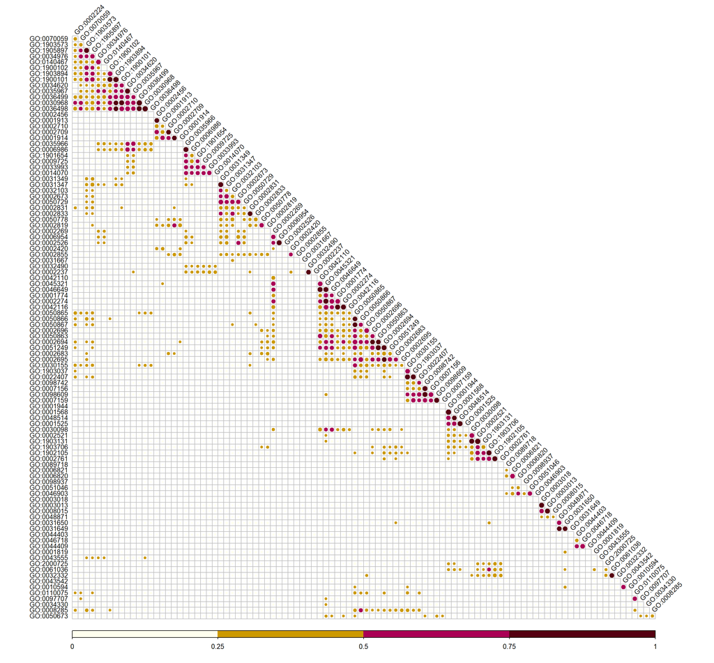

And by selecting different similarity scores threshold, let’s visualize a network of our enriched terms

### Sim0.5

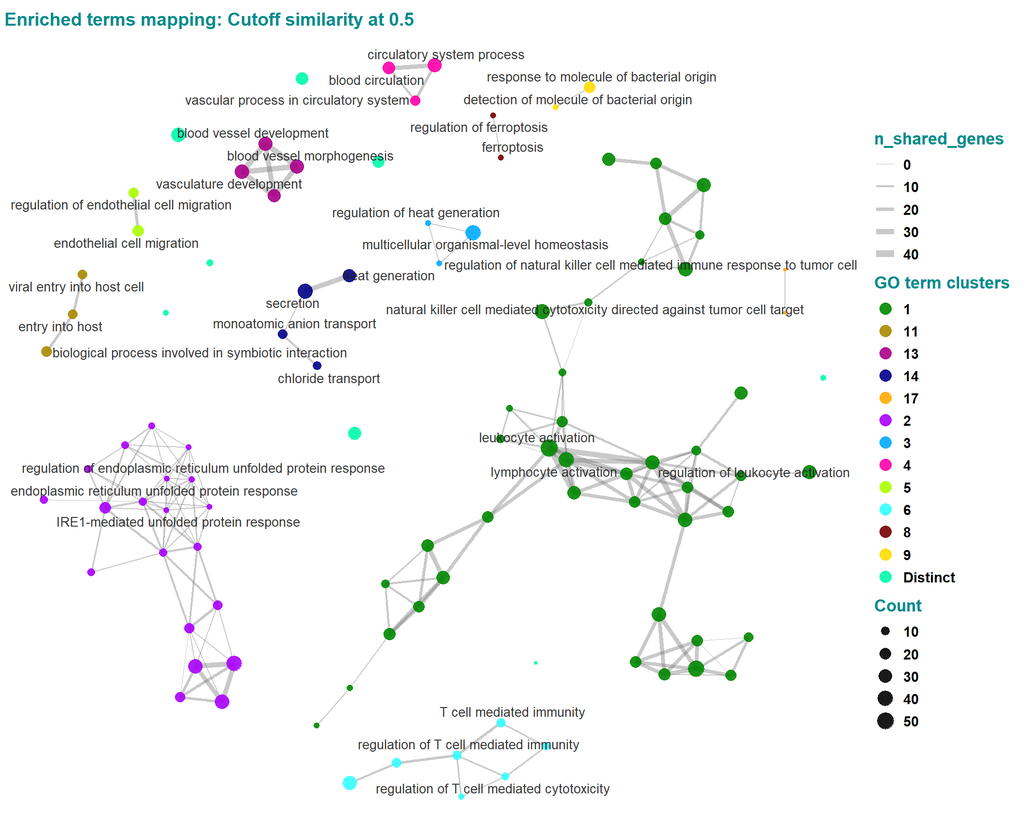

### Sim0.6

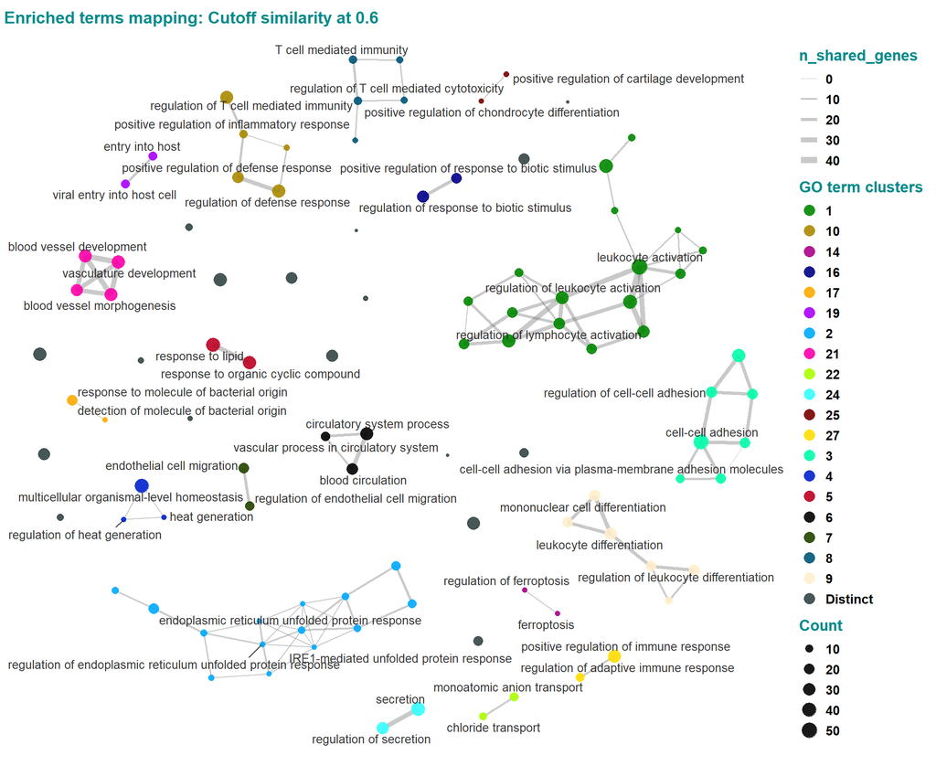

### Sim0.7

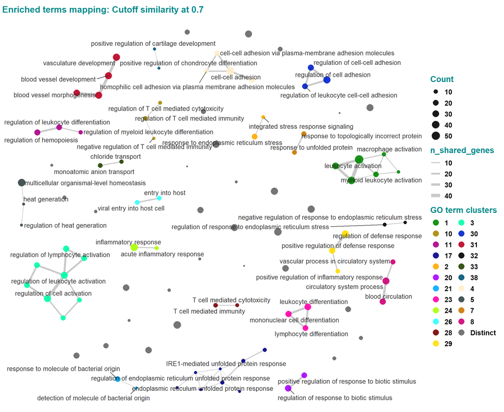

### Sim0.8

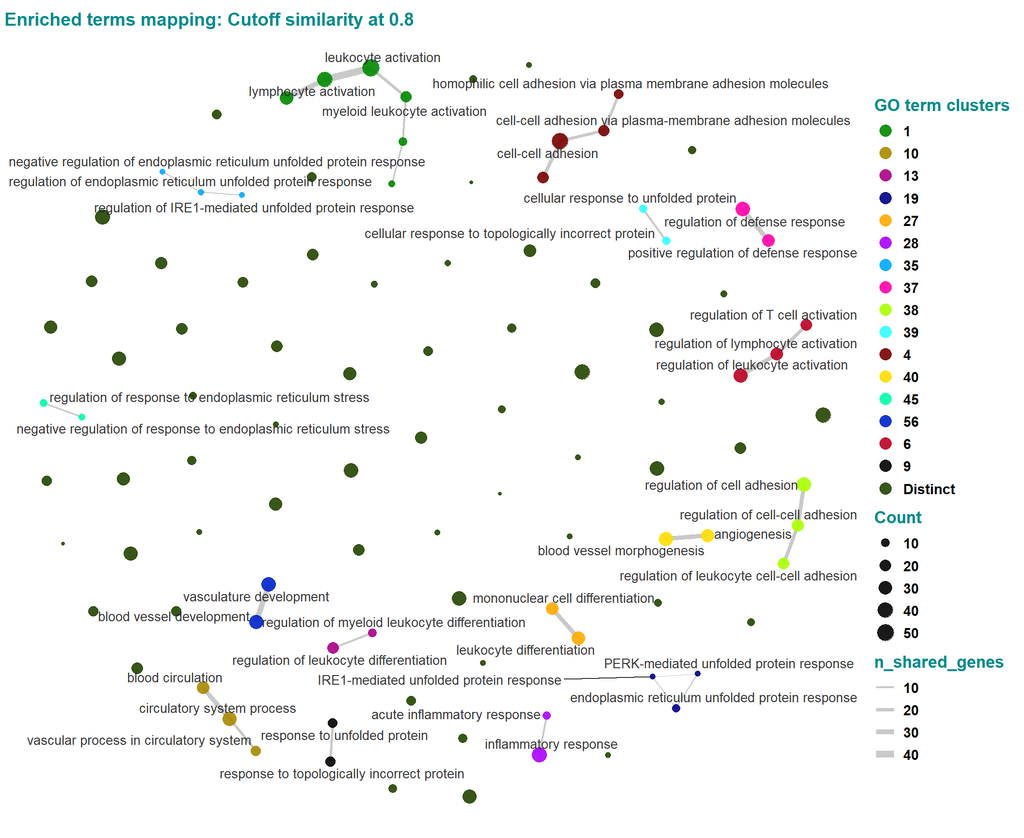

## Clusters annotation

Now let’s prepare our list for cluster annotation.

We’ll use `Sims0.7` results as cluster grouping, below are the different clusters.

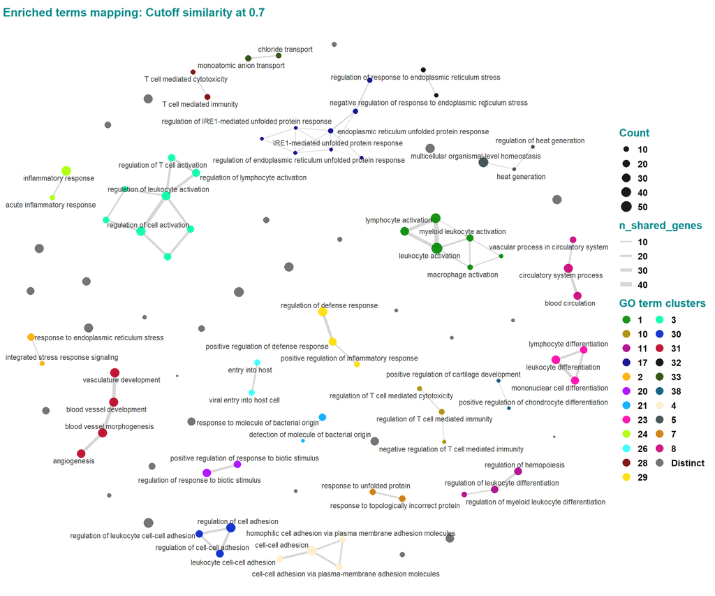

Below is the complete list of terms within each cluster

```
## Cluster ===>  1
## =============================
## leukocyte activation
## lymphocyte activation
## myeloid leukocyte activation
## T cell activation
## macrophage activation
## microglial cell activation
##
##
## Cluster ===>  2
## =============================
## response to endoplasmic reticulum stress
## integrated stress response signaling
##
##
## Cluster ===>  3
## =============================
## regulation of cell activation
## regulation of leukocyte activation
## negative regulation of cell activation
## negative regulation of leukocyte activation
## positive regulation of cell activation
## regulation of lymphocyte activation
## positive regulation of leukocyte activation
## regulation of T cell activation
##
##
## Cluster ===>  4
## =============================
## cell-cell adhesion
## cell-cell adhesion via plasma-membrane adhesion molecules
## homophilic cell adhesion via plasma membrane adhesion molecules
## leukocyte cell-cell adhesion
##
##
## Cluster ===>  5
## =============================
## multicellular organismal-level homeostasis
## regulation of heat generation
```

[output cut: 102 more lines]

```
## =============================
## negative regulation of response to endoplasmic reticulum stress
## regulation of response to endoplasmic reticulum stress
##
##
## Cluster ===>  33
## =============================
## chloride transport
## monoatomic anion transport
##
##
## Cluster ===>  38
## =============================
## positive regulation of cartilage development
## positive regulation of chondrocyte differentiation
```

And now, annotating the clusters accordingly!

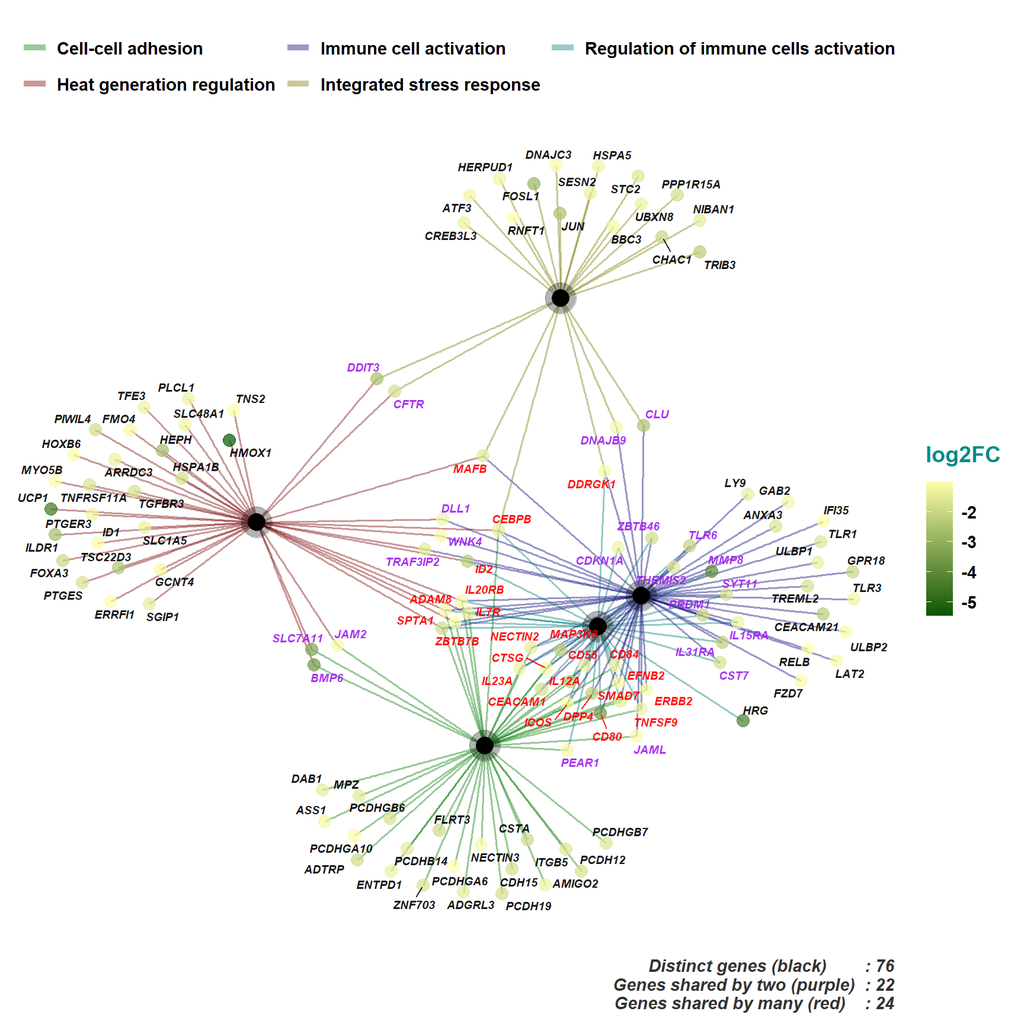

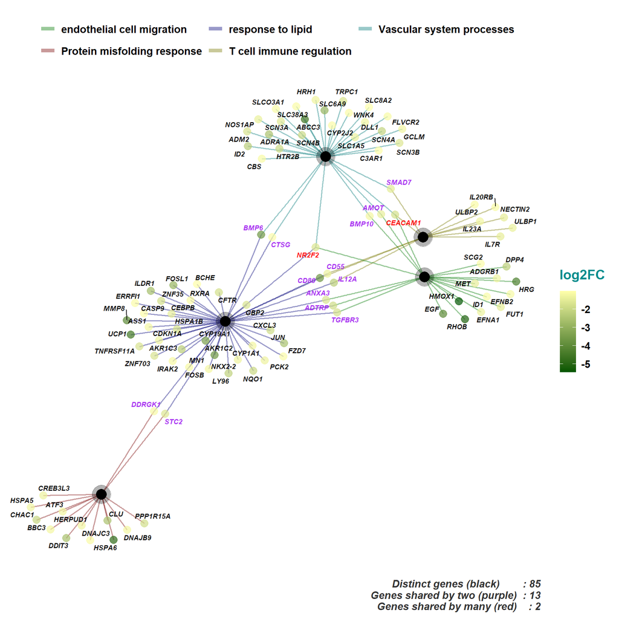

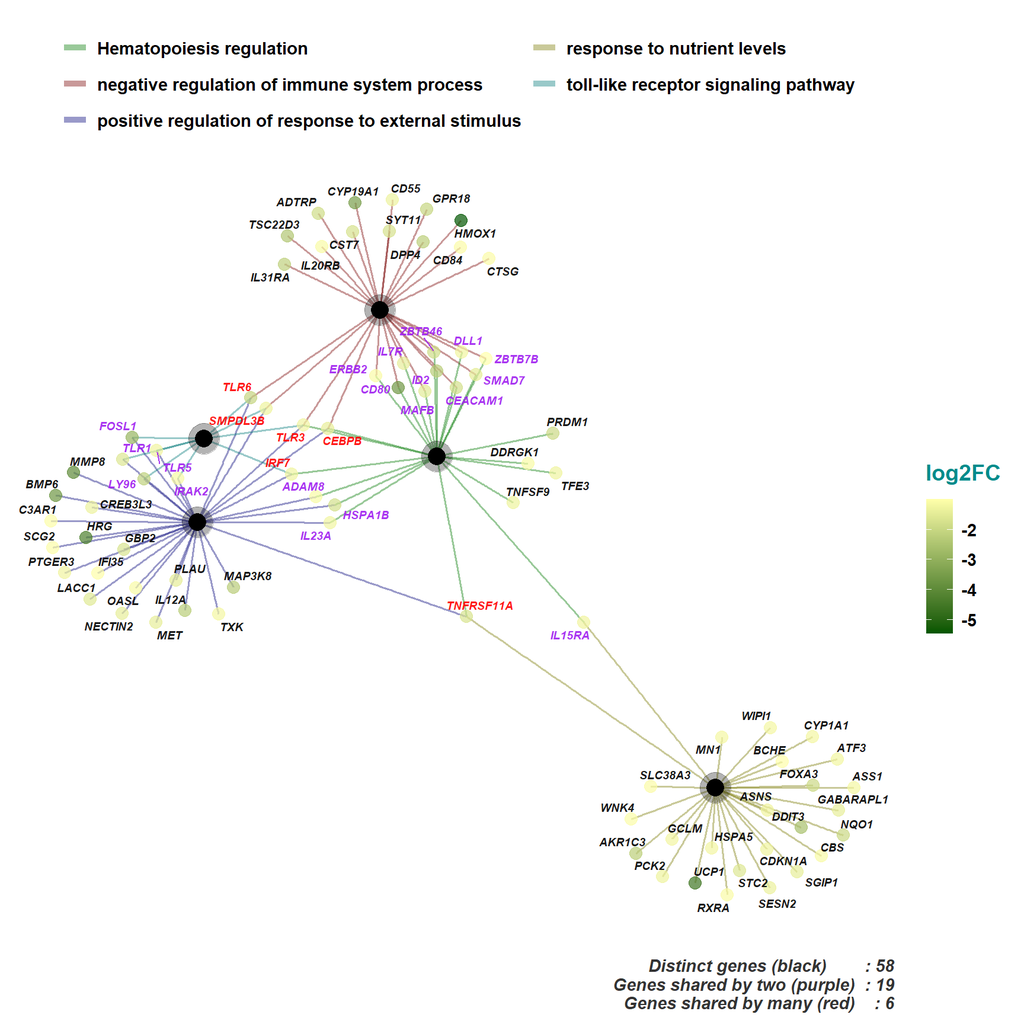

```r
clusters_df <- clusters_df %>%
  dplyr::mutate(
    superTerm = dplyr::case_when(
      cluster == "1"  ~ "Immune cell activation",
      cluster == "2"  ~ "Integrated stress response",
      cluster == "3"  ~ "Regulation of immune cells activation",
      cluster == "4"  ~ "Cell-cell adhesion",
      cluster == "5"  ~ "Heat generation regulation",
      cluster == "7"  ~ "Protein misfolding response",
      cluster == "8"  ~ "Vascular system processes",
      cluster == "10" ~ "T cell immune regulation",
      cluster == "11" ~ "Hematopoiesis regulation",
      cluster == "17" ~ "ER unfolded protein response",
      cluster == "20" ~ "Response to biotic signals",
      cluster == "21" ~ "Bacterial molecule detection and response",
      cluster == "23" ~ "Lymphoid lineage differentiation",
      cluster == "24" ~ "Inflammatory response",
      cluster == "26" ~ "Viral host entry",
      cluster == "28" ~ "T cell mediated immunity and cytotoxicity",
      cluster == "29" ~ "Defense response activation",
      cluster == "30" ~ "Cell adhesion regulation",
      cluster == "31" ~ "Angiogenesis processes",
      cluster == "32" ~ "ER stress regulation",
      cluster == "33" ~ "Chloride transport",
      cluster == "38" ~ "Chondrocyte differentiation and cartilage development",
      TRUE ~ cluster
    )
  )
```